# Laboratorio 4.1: Distancias y Medidas de Similitud

Author

Minería de Datos - Grado en Matemáticas

# Introducción

En este laboratorio trabajaremos con **distancias y medidas de similitud**, que son fundamentales para el aprendizaje basado en similitud. Nos centraremos en:

- **Distancias para datos continuos** (Euclídea, Manhattan, Minkowski, Chebyshev)
- **Distancias para datos binarios** (Jaccard, Simple Matching, etc.)
- **Distancias para datos categóricos** (Hamming, Gower)
- **Distancias para datos mixtos**
- **Visualización de matrices de distancia**

## Objetivos del laboratorio

1. Comprender las diferentes medidas de distancia y cuándo aplicar cada una
2. Implementar y comparar distintas métricas de distancia
3. Analizar el efecto de la escala en las distancias
4. Trabajar con datos de diferentes tipos (continuos, binarios, categóricos, mixtos)
5. Visualizar y interpretar matrices de distancia

# Configuración inicial

```r
# Librerías necesarias
library(tidyverse)
library(ggplot2)
library(cluster)
library(pheatmap)
library(proxy)
library(gower)
library(factoextra)

# Configuración de gráficos
theme_set(theme_minimal())
```

# Parte 1: Distancias para Datos Continuos

## 1.1 Fundamentos de las Distancias

### Ejercicio 1.1: Distancias básicas - Cálculo manual

**Objetivo**: Calcular manualmente diferentes distancias para comprender sus propiedades.

```r
# Definir dos puntos en 4 dimensiones
x <- c(2, 4, 1, 3)
y <- c(5, 2, 3, 6)

cat("Punto x:", x, "\n")
```

```
Punto x: 2 4 1 3
```

```r
cat("Punto y:", y, "\n\n")
```

```
Punto y: 5 2 3 6
```

```r
# 1. Distancia Euclídea (L2)
dist_euclidean <- sqrt(sum((x - y)^2))
cat("Distancia Euclídea:", round(dist_euclidean, 4), "\n")
```

```
Distancia Euclídea: 5.099
```

```r
cat("Fórmula: sqrt(sum((x - y)²))\n")
```

```
Fórmula: sqrt(sum((x - y)²))
```

```r
cat("Cálculo: sqrt((2-5)² + (4-2)² + (1-3)² + (3-6)²)\n")
```

```
Cálculo: sqrt((2-5)² + (4-2)² + (1-3)² + (3-6)²)
```

```r
cat("        = sqrt(9 + 4 + 4 + 9) = sqrt(26) =", round(dist_euclidean, 4), "\n\n")
```

```
        = sqrt(9 + 4 + 4 + 9) = sqrt(26) = 5.099
```

```r
# 2. Distancia Manhattan (L1)
dist_manhattan <- sum(abs(x - y))
cat("Distancia Manhattan:", dist_manhattan, "\n")
```

```
Distancia Manhattan: 10
```

```r
cat("Fórmula: sum(|x - y|)\n")
```

```
Fórmula: sum(|x - y|)
```

```r
cat("Cálculo: |2-5| + |4-2| + |1-3| + |3-6|\n")
```

```
Cálculo: |2-5| + |4-2| + |1-3| + |3-6|
```

```r
cat("        = 3 + 2 + 2 + 3 =", dist_manhattan, "\n\n")
```

```
        = 3 + 2 + 2 + 3 = 10
```

```r
# 3. Distancia Minkowski (L3)
p <- 3
dist_minkowski_3 <- (sum(abs(x - y)^p))^(1/p)
cat("Distancia Minkowski (p=3):", round(dist_minkowski_3, 4), "\n")
```

```
Distancia Minkowski (p=3): 4.1213
```

```r
cat("Fórmula: (sum(|x - y|^p))^(1/p)\n")
```

```
Fórmula: (sum(|x - y|^p))^(1/p)
```

```r
cat("Cálculo: (3³ + 2³ + 2³ + 3³)^(1/3)\n")
```

```
Cálculo: (3³ + 2³ + 2³ + 3³)^(1/3)
```

```r
cat("        = (27 + 8 + 8 + 27)^(1/3) =", round(dist_minkowski_3, 4), "\n\n")
```

```
        = (27 + 8 + 8 + 27)^(1/3) = 4.1213
```

```r
# 4. Distancia Chebyshev (L∞)
dist_chebyshev <- max(abs(x - y))
cat("Distancia Chebyshev (L∞):", dist_chebyshev, "\n")
```

```
Distancia Chebyshev (L∞): 3
```

```r
cat("Fórmula: max(|x - y|)\n")
```

```
Fórmula: max(|x - y|)
```

```r
cat("Cálculo: max(|2-5|, |4-2|, |1-3|, |3-6|)\n")
```

```
Cálculo: max(|2-5|, |4-2|, |1-3|, |3-6|)
```

```r
cat("        = max(3, 2, 2, 3) =", dist_chebyshev, "\n\n")
```

```
        = max(3, 2, 2, 3) = 3
```

```r
# Resumen comparativo
cat("=== RESUMEN COMPARATIVO ===\n")
```

```
=== RESUMEN COMPARATIVO ===
```

```r
dist_summary <- data.frame(
  Métrica = c("Manhattan (L1)", "Euclídea (L2)", "Minkowski (L3)", "Chebyshev (L∞)"),
  Valor = c(dist_manhattan, dist_euclidean, dist_minkowski_3, dist_chebyshev),
  Interpretación = c(
    "Suma de diferencias absolutas",
    "Línea recta entre puntos",
    "Intermedia entre L2 y L∞",
    "Máxima diferencia en cualquier dimensión"
  )
)
print(dist_summary)
```

```
         Métrica     Valor                           Interpretación
1 Manhattan (L1) 10.000000            Suma de diferencias absolutas
2  Euclídea (L2)  5.099020                 Línea recta entre puntos
3 Minkowski (L3)  4.121285                 Intermedia entre L2 y L∞
4 Chebyshev (L∞)  3.000000 Máxima diferencia en cualquier dimensión
```

**Pregunta 1**: ¿Qué relación observas entre los valores de las diferentes distancias? ¿Cuál es siempre la más pequeña y cuál la más grande?

### Ejercicio 1.2: Efecto del parámetro p en Minkowski

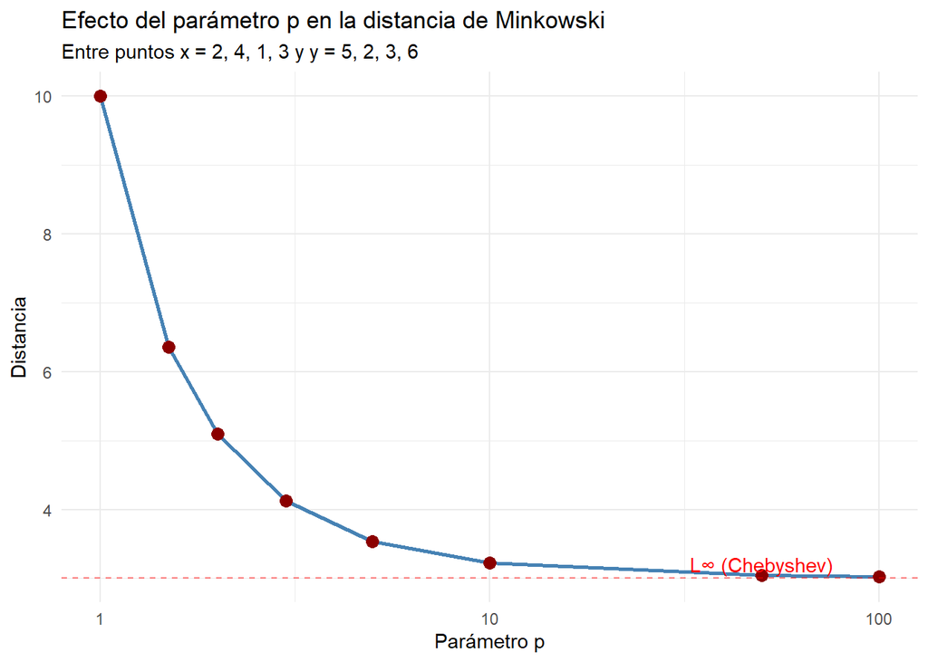

```r
# Calcular distancias de Minkowski para diferentes valores de p
p_values <- c(1, 1.5, 2, 3, 5, 10, 50, 100)
dist_values <- sapply(p_values, function(p) {
  (sum(abs(x - y)^p))^(1/p)
})

# Crear dataframe
minkowski_df <- data.frame(
  p = p_values,
  distancia = dist_values
)

# Visualizar
ggplot(minkowski_df, aes(x = p, y = distancia)) +
  geom_line(color = "steelblue", size = 1) +
  geom_point(color = "darkred", size = 3) +
  geom_hline(yintercept = dist_chebyshev, linetype = "dashed",
             color = "red", alpha = 0.5) +
  annotate("text", x = 50, y = dist_chebyshev + 0.2,
           label = "L∞ (Chebyshev)", color = "red") +
  labs(title = "Efecto del parámetro p en la distancia de Minkowski",
       subtitle = paste("Entre puntos x =", paste(x, collapse = ", "),
                       "y y =", paste(y, collapse = ", ")),
       x = "Parámetro p",
       y = "Distancia") +
  scale_x_log10() +
  theme_minimal()
```

```r
cat("\nInterpretación:\n")
```

```
Interpretación:
```

```r
cat("- A medida que p aumenta, la distancia converge a L∞ (Chebyshev)\n")
```

```
- A medida que p aumenta, la distancia converge a L∞ (Chebyshev)
```

```r
cat("- p=1: Manhattan (distancia de taxi)\n")
```

```
- p=1: Manhattan (distancia de taxi)
```

```r
cat("- p=2: Euclídea (distancia más común)\n")
```

```
- p=2: Euclídea (distancia más común)
```

```r
cat("- p→∞: Chebyshev (máxima diferencia)\n")
```

```
- p→∞: Chebyshev (máxima diferencia)
```

```r
cat("- Valores grandes de p dan más peso a las diferencias grandes\n")
```

```
- Valores grandes de p dan más peso a las diferencias grandes
```

**Pregunta 2**: ¿Por qué la distancia de Minkowski converge a la distancia de Chebyshev cuando p tiende a infinito?

### Ejercicio 1.2b: Distancia Coseno

**Objetivo**: Comprender la distancia coseno, especialmente útil en alta dimensionalidad y text mining.

```r
cat("=== DISTANCIA COSENO ===\n\n")
```

```
=== DISTANCIA COSENO ===
```

```r
# Definir vectores (pueden representar documentos, perfiles de usuario, etc.)
doc1 <- c(3, 2, 0, 5, 0, 0, 1, 2)  # Frecuencia de 8 palabras
doc2 <- c(2, 1, 0, 3, 0, 0, 1, 1)  # Documento similar
doc3 <- c(0, 0, 1, 0, 2, 3, 0, 0)  # Documento diferente

cat("Vectores de frecuencia de palabras:\n")
```

```
Vectores de frecuencia de palabras:
```

```r
cat("doc1:", doc1, "\n")
```

```
doc1: 3 2 0 5 0 0 1 2
```

```r
cat("doc2:", doc2, "\n")
```

```
doc2: 2 1 0 3 0 0 1 1
```

```r
cat("doc3:", doc3, "\n\n")
```

```
doc3: 0 0 1 0 2 3 0 0
```

```r
# Calcular similitud coseno manualmente
cosine_sim <- function(x, y) {
  sum(x * y) / (sqrt(sum(x^2)) * sqrt(sum(y^2)))
}

# Calcular distancia coseno (1 - similitud)
cosine_dist <- function(x, y) {
  1 - cosine_sim(x, y)
}

cat("=== SIMILITUD COSENO ===\n")
```

```
=== SIMILITUD COSENO ===
```

```r
cat(sprintf("cos_sim(doc1, doc2) = %.4f (vectores similares)\n", cosine_sim(doc1, doc2)))
```

```
cos_sim(doc1, doc2) = 0.9912 (vectores similares)
```

```r
cat(sprintf("cos_sim(doc1, doc3) = %.4f (vectores diferentes)\n", cosine_sim(doc1, doc3)))
```

```
cos_sim(doc1, doc3) = 0.0000 (vectores diferentes)
```

```r
cat(sprintf("cos_sim(doc2, doc3) = %.4f (vectores diferentes)\n\n", cosine_sim(doc2, doc3)))
```

```
cos_sim(doc2, doc3) = 0.0000 (vectores diferentes)
```

```r
cat("=== DISTANCIA COSENO ===\n")
```

```
=== DISTANCIA COSENO ===
```

```r
cat(sprintf("cos_dist(doc1, doc2) = %.4f\n", cosine_dist(doc1, doc2)))
```

```
cos_dist(doc1, doc2) = 0.0088
```

```r
cat(sprintf("cos_dist(doc1, doc3) = %.4f\n", cosine_dist(doc1, doc3)))
```

```
cos_dist(doc1, doc3) = 1.0000
```

```r
cat(sprintf("cos_dist(doc2, doc3) = %.4f\n\n", cosine_dist(doc2, doc3)))
```

```
cos_dist(doc2, doc3) = 1.0000
```

```r
# Comparar con distancia Euclídea
cat("=== COMPARACIÓN CON DISTANCIA EUCLÍDEA ===\n")
```

```
=== COMPARACIÓN CON DISTANCIA EUCLÍDEA ===
```

```r
cat(sprintf("eucl(doc1, doc2) = %.4f\n", sqrt(sum((doc1 - doc2)^2))))
```

```
eucl(doc1, doc2) = 2.6458
```

```r
cat(sprintf("eucl(doc1, doc3) = %.4f\n", sqrt(sum((doc1 - doc3)^2))))
```

```
eucl(doc1, doc3) = 7.5498
```

```r
cat(sprintf("eucl(doc2, doc3) = %.4f\n\n", sqrt(sum((doc2 - doc3)^2))))
```

```
eucl(doc2, doc3) = 5.4772
```

```r
# Ejemplo con escalas diferentes (ventaja de coseno)
cat("=== VENTAJA DE COSENO: INVARIANTE A LA ESCALA ===\n")
```

```
=== VENTAJA DE COSENO: INVARIANTE A LA ESCALA ===
```

```r
doc1_scaled <- doc1 * 10  # Documento 1 escalado 10x
cat("doc1_scaled:", doc1_scaled, "\n\n")
```

```
doc1_scaled: 30 20 0 50 0 0 10 20
```

```r
cat("Distancia Euclídea es sensible a la escala:\n")
```

```
Distancia Euclídea es sensible a la escala:
```

```r
cat(sprintf("  eucl(doc1, doc2) = %.4f\n", sqrt(sum((doc1 - doc2)^2))))
```

```
  eucl(doc1, doc2) = 2.6458
```

```r
cat(sprintf("  eucl(doc1_scaled, doc2) = %.4f (¡cambió mucho!)\n\n",
            sqrt(sum((doc1_scaled - doc2)^2))))
```

```
  eucl(doc1_scaled, doc2) = 61.6117 (¡cambió mucho!)
```

```r
cat("Distancia Coseno es INVARIANTE a la escala:\n")
```

```
Distancia Coseno es INVARIANTE a la escala:
```

```r
cat(sprintf("  cos_dist(doc1, doc2) = %.4f\n", cosine_dist(doc1, doc2)))
```

```
  cos_dist(doc1, doc2) = 0.0088
```

```r
cat(sprintf("  cos_dist(doc1_scaled, doc2) = %.4f (¡igual!)\n\n",
            cosine_dist(doc1_scaled, doc2)))
```

```
  cos_dist(doc1_scaled, doc2) = 0.0088 (¡igual!)
```

```r
# Usar proxy para calcular distancia coseno
docs <- rbind(doc1, doc2, doc3)
rownames(docs) <- c("doc1", "doc2", "doc3")

dist_coseno <- proxy::dist(docs, method = "cosine")
cat("=== MATRIZ DE DISTANCIAS COSENO ===\n")
```

```
=== MATRIZ DE DISTANCIAS COSENO ===
```

```r
print(round(as.matrix(dist_coseno), 4))
```

```
       doc1   doc2 doc3
doc1 0.0000 0.0088    1
doc2 0.0088 0.0000    1
doc3 1.0000 1.0000    0
```

```r
# Visualización
par(mfrow = c(1, 2))

# Gráfico 2D de primeras dos dimensiones
cat("\nNOTA: El gráfico 2D muestra solo las primeras 2 dimensiones (palabras 1 y 2)\n")
```

```
NOTA: El gráfico 2D muestra solo las primeras 2 dimensiones (palabras 1 y 2)
```

```r
cat("de vectores de 8 dimensiones. Es una PROYECCIÓN PARCIAL para visualización.\n")
```

```
de vectores de 8 dimensiones. Es una PROYECCIÓN PARCIAL para visualización.
```

```r
cat("Los cálculos de distancia coseno usan TODAS las 8 dimensiones.\n\n")
```

```
Los cálculos de distancia coseno usan TODAS las 8 dimensiones.
```

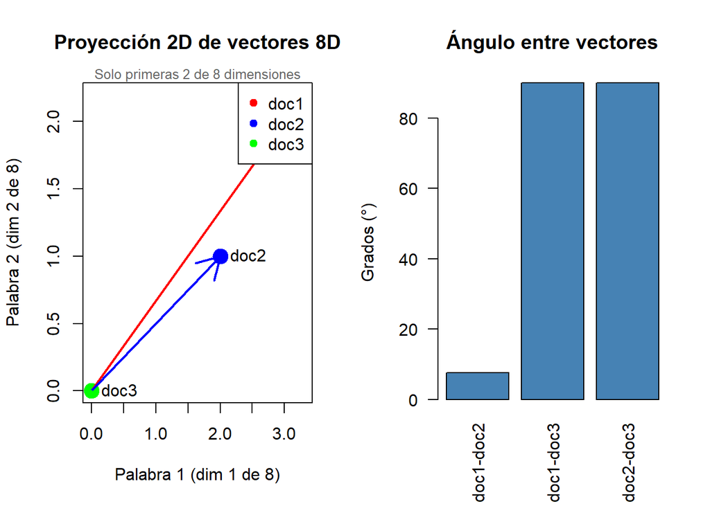

```r
plot(docs[, 1], docs[, 2], pch = 19, cex = 2, col = c("red", "blue", "green"),
     xlim = c(0, max(docs[, 1])*1.1), ylim = c(0, max(docs[, 2])*1.1),
     xlab = "Palabra 1 (dim 1 de 8)", ylab = "Palabra 2 (dim 2 de 8)",
     main = "Proyección 2D de vectores 8D")
text(docs[, 1], docs[, 2], labels = rownames(docs), pos = 4)
# Dibujar vectores desde origen
arrows(0, 0, docs[, 1], docs[, 2], col = c("red", "blue", "green"), lwd = 2)
legend("topright", legend = rownames(docs), col = c("red", "blue", "green"), pch = 19)
mtext("Solo primeras 2 de 8 dimensiones", side = 3, line = 0, cex = 0.8, col = "gray40")

# Ángulos entre vectores
angle_12 <- acos(cosine_sim(doc1, doc2)) * 180 / pi
angle_13 <- acos(cosine_sim(doc1, doc3)) * 180 / pi
angle_23 <- acos(cosine_sim(doc2, doc3)) * 180 / pi

barplot(c(angle_12, angle_13, angle_23),
        names.arg = c("doc1-doc2", "doc1-doc3", "doc2-doc3"),
        col = "steelblue", las = 2,
        main = "Ángulo entre vectores",
        ylab = "Grados (°)")
```

```r
par(mfrow = c(1, 1))

cat("\n=== INTERPRETACIÓN DE DISTANCIA COSENO ===\n")
```

```
=== INTERPRETACIÓN DE DISTANCIA COSENO ===
```

```r
cat("- Mide el ángulo entre vectores (no la magnitud)\n")
```

```
- Mide el ángulo entre vectores (no la magnitud)
```

```r
cat("- Rango teórico: [0, 2]\n")
```

```
- Rango teórico: [0, 2]
```

```r
cat("  · [0, 1] para vectores NO NEGATIVOS (ej: frecuencias, counts)\n")
```

```
  · [0, 1] para vectores NO NEGATIVOS (ej: frecuencias, counts)
```

```r
cat("  · [0, 2] si vectores pueden tener valores NEGATIVOS\n")
```

```
  · [0, 2] si vectores pueden tener valores NEGATIVOS
```

```r
cat("- 0: vectores idénticos en dirección (ángulo = 0°)\n")
```

```
- 0: vectores idénticos en dirección (ángulo = 0°)
```

```r
cat("- 1: vectores ortogonales (ángulo = 90°)\n")
```

```
- 1: vectores ortogonales (ángulo = 90°)
```

```r
cat("- 2: vectores completamente opuestos (ángulo = 180°)\n")
```

```
- 2: vectores completamente opuestos (ángulo = 180°)
```

```r
cat("\nEn NLP y text mining, típicamente [0, 1] porque frecuencias ≥ 0\n")
```

```
En NLP y text mining, típicamente [0, 1] porque frecuencias ≥ 0
```

```r
cat("\n=== CUÁNDO USAR DISTANCIA COSENO ===\n")
```

```
=== CUÁNDO USAR DISTANCIA COSENO ===
```

```r
cat("✓ Text mining y NLP (frecuencia de palabras)\n")
```

```
✓ Text mining y NLP (frecuencia de palabras)
```

```r
cat("✓ Sistemas de recomendación (perfiles de usuario)\n")
```

```
✓ Sistemas de recomendación (perfiles de usuario)
```

```r
cat("✓ Alta dimensionalidad con datos dispersos\n")
```

```
✓ Alta dimensionalidad con datos dispersos
```

```r
cat("✓ Cuando la magnitud no importa, solo la dirección\n")
```

```
✓ Cuando la magnitud no importa, solo la dirección
```

```r
cat("✓ Clasificación de documentos\n")
```

```
✓ Clasificación de documentos
```

```r
cat("✗ No usar si la magnitud es importante\n")
```

```
✗ No usar si la magnitud es importante
```

```r
cat("✗ No apropiada para datos con valores negativos relevantes\n")
```

```
✗ No apropiada para datos con valores negativos relevantes
```

**Pregunta 2b**: ¿Por qué la distancia coseno es preferible a la euclídea para comparar documentos?

## 1.2 Distancias en Datasets Reales

### Ejercicio 1.3: Comparación de distancias con Iris

```r
# Usar solo variables numéricas
data(iris)
X <- iris[, 1:4]

# NOTA: Aquí NO estandarizamos para observar diferencias entre métricas
# Ver Ejercicio 1.4 para entender por qué la estandarización es crucial

# Seleccionar 3 observaciones de ejemplo
idx <- c(1, 51, 101)  # Una de cada especie
X_sample <- X[idx, ]
rownames(X_sample) <- paste("Obs", idx, "-", iris$Species[idx])

cat("=== OBSERVACIONES SELECCIONADAS ===\n")
```

```
=== OBSERVACIONES SELECCIONADAS ===
```

```r
print(X_sample)
```

```
                    Sepal.Length Sepal.Width Petal.Length Petal.Width
Obs 1 - setosa               5.1         3.5          1.4         0.2
Obs 51 - versicolor          7.0         3.2          4.7         1.4
Obs 101 - virginica          6.3         3.3          6.0         2.5
```

```r
# Calcular diferentes distancias
dist_euclidean <- dist(X_sample, method = "euclidean")
dist_manhattan <- dist(X_sample, method = "manhattan")
dist_minkowski_3 <- dist(X_sample, method = "minkowski", p = 3)
dist_maximum <- dist(X_sample, method = "maximum")  # Chebyshev

# Mostrar resultados
cat("\n=== MATRICES DE DISTANCIA ===\n\n")
```

```
=== MATRICES DE DISTANCIA ===
```

```r
cat("Distancia Euclídea:\n")
```

```
Distancia Euclídea:
```

```r
print(round(as.matrix(dist_euclidean), 3))
```

```
                    Obs 1 - setosa Obs 51 - versicolor Obs 101 - virginica
Obs 1 - setosa               0.000               4.004               5.285
Obs 51 - versicolor          4.004               0.000               1.844
Obs 101 - virginica          5.285               1.844               0.000
```

```r
cat("\nDistancia Manhattan:\n")
```

```
Distancia Manhattan:
```

```r
print(round(as.matrix(dist_manhattan), 3))
```

```
                    Obs 1 - setosa Obs 51 - versicolor Obs 101 - virginica
Obs 1 - setosa                 0.0                 6.7                 8.3
Obs 51 - versicolor            6.7                 0.0                 3.2
Obs 101 - virginica            8.3                 3.2                 0.0
```

```r
cat("\nDistancia Minkowski (p=3):\n")
```

```
Distancia Minkowski (p=3):
```

```r
print(round(as.matrix(dist_minkowski_3), 3))
```

```
                    Obs 1 - setosa Obs 51 - versicolor Obs 101 - virginica
Obs 1 - setosa               0.000               3.545               4.809
Obs 51 - versicolor          3.545               0.000               1.570
Obs 101 - virginica          4.809               1.570               0.000
```

```r
cat("\nDistancia Chebyshev (L∞):\n")
```

```
Distancia Chebyshev (L∞):
```

```r
print(round(as.matrix(dist_maximum), 3))
```

```
                    Obs 1 - setosa Obs 51 - versicolor Obs 101 - virginica
Obs 1 - setosa                 0.0                 3.3                 4.6
Obs 51 - versicolor            3.3                 0.0                 1.3
Obs 101 - virginica            4.6                 1.3                 0.0
```

```r
# Comparar rankings
cat("\n=== COMPARACIÓN DE RANKINGS ===\n")
```

```
=== COMPARACIÓN DE RANKINGS ===
```

```r
cat("¿Qué observación está más cerca de la Obs 1?\n\n")
```

```
¿Qué observación está más cerca de la Obs 1?
```

```r
comp_df <- data.frame(
  Métrica = c("Euclídea", "Manhattan", "Minkowski p=3", "Chebyshev"),
  Distancia_a_Obs51 = c(
    as.matrix(dist_euclidean)[1, 2],
    as.matrix(dist_manhattan)[1, 2],
    as.matrix(dist_minkowski_3)[1, 2],
    as.matrix(dist_maximum)[1, 2]
  ),
  Distancia_a_Obs101 = c(
    as.matrix(dist_euclidean)[1, 3],
    as.matrix(dist_manhattan)[1, 3],
    as.matrix(dist_minkowski_3)[1, 3],
    as.matrix(dist_maximum)[1, 3]
  )
)
comp_df$Más_cercano <- ifelse(comp_df$Distancia_a_Obs51 < comp_df$Distancia_a_Obs101,
                               "Obs 51", "Obs 101")
print(comp_df)
```

```
        Métrica Distancia_a_Obs51 Distancia_a_Obs101 Más_cercano
1      Euclídea          4.003748           5.284884      Obs 51
2     Manhattan          6.700000           8.300000      Obs 51
3 Minkowski p=3          3.545024           4.809342      Obs 51
4     Chebyshev          3.300000           4.600000      Obs 51
```

**Pregunta 3**: ¿Todas las métricas coinciden en cuál es la observación más cercana? ¿Por qué?